# Random forest analysis for BSL questions

Bodo Winter

03/02/2022

## Setup

Load packages:

```r
library(tidyverse)
library(ranger) # for random forest analysis
library(tuneRanger) # for tuning random forests
```

Package versions:

```r
packageVersion('ranger')
```

```
## [1] '0.15.1'
```

```r
packageVersion('tuneRanger')
```

```
## [1] '0.5'
```

Load helper functions:

```r
source('question_helper_functions.R')
```

Load cleaned data, which is the output from the `preprocessing.Rmd` script:

```r
df <- read_csv('../data/BSL_questions_cleaned.csv')
```

## Exclusions

Following the “turning points” in the `descriptive_statistics.Rmd` file we need to exclude constructed actions as well as “other” and “alternative” questions:

```r
df <- filter(df,
             has_CA == 'no CA',
             semantic %in% c('Content', 'Polar'))
```

## Create a vector of form features

Create a vector that contains all the form variables.

```r
pred_vector <- c('any_head_movement', 'any_head_nod', 'any_head_forward',
                 'any_head_backward', 'any_head_sideward', 'any_head_shake',
                 'any_head_up', 'any_head_down', 'any_eye_brow',
                 'any_eye_brow_up', 'any_eye_brow_down',
                 'any_eye_brow_squint', 'any_eye_brow_wide',
                 'mouthing_question',
                 'manual', 'nonmanual')
```

## Predicitng polar versus content questions

Random forest analysis, make this into a task object for tuneRanger:

```r
# Select only columns that are relevant to the task at hand:

df_task <- bind_cols(select(df, pred_vector),
                     select(df, semantic))
# Make all columns into factors:

df_task <- df_task %>% mutate_all(as.factor)

# Make into data frames:

polars_task <- as.data.frame(df_task)

# Make into task object:

polars_task <- makeClassifTask(data = polars_task, target = 'semantic')
```

Check the estimated runtime:

```r
estimateTimeTuneRanger(polars_task)
```

```
## Approximated time for tuning: 1M 16S
```

Easy enough, about a minute!

Let’s tune the tree:

```r
set.seed(666) # set random seed value to a nice comforting number

polars_tunes <- tuneRanger(polars_task, measure = list(multiclass.brier),
                           num.trees = 1000, num.threads = 4,
                           iters = 70, iters.warmup = 30)
```

Check results:

```r
polars_tunes
```

```
## Recommended parameter settings:
##   mtry min.node.size sample.fraction
## 1   14            59       0.2567078
## Results:
##   multiclass.brier exec.time
## 1        0.1546146    0.1966
```

Run ranger with the new tuned hyperparameters. But first we need a new formula:

```r
rf_formula <- str_c(pred_vector, collapse = ' + ')
rf_formula <- str_c('semantic ~ ', rf_formula)
rf_formula <- as.formula(rf_formula)

# Check:

rf_formula
```

```
## semantic ~ any_head_movement + any_head_nod + any_head_forward +
##     any_head_backward + any_head_sideward + any_head_shake +
##     any_head_up + any_head_down + any_eye_brow + any_eye_brow_up +
##     any_eye_brow_down + any_eye_brow_squint + any_eye_brow_wide +
##     mouthing_question + manual + nonmanual
```

Make main dependent variable into factor:

```r
df <- mutate(df,
             semantic = factor(semantic))
```

Then run the forest:

```r
set.seed(666) # set seed to a nice number
polar_forest <- ranger(rf_formula, data = df,

                       # Tuned hyperparameters:

                       mtry = 14,
                       min.node.size = 59,
                       sample.fraction = 0.2567078,

                       # Other parameter settings:

                       importance = 'permutation',
                       num.trees = 1000,
                       num.threads = 4,
                       seed = 666) # set seed to a nice comforting number
```

Show the forest:

```r
polar_forest
```

```
## Ranger result
##
## Call:
##  ranger(rf_formula, data = df, mtry = 14, min.node.size = 59,      sample.fraction = 0.2567078, importance = "permutation",      num.trees = 1000, num.threads = 4, seed = 666)
##
## Type:                             Classification
## Number of trees:                  1000
## Sample size:                      556
## Number of independent variables:  16
## Mtry:                             14
## Target node size:                 59
## Variable importance mode:         permutation
## Splitrule:                        gini
## OOB prediction error:             8.63 %
```

Relatively low OOB error = good.

Create a contingency table of real versus predicted values:

```r
class_tab <- table(df$semantic,
                   predict(polar_forest, data = df)$predictions)

# Check:

class_tab
```

```
##
##           Content Polar
##   Content     105    35
##   Polar        13   403
```

Check the accuracy (which is the diagonal):

```r
sum(diag(class_tab)) / sum(class_tab)
```

```
## [1] 0.9136691
```

About 91%…. and a low OOB error.

Let’s check the variable importances:

```r
importances <- polar_forest$variable.importance

# Put it into a tibble:

importances <- tibble(predictor = names(importances),
                      importance = as.vector(importances)) %>%
  arrange(desc(importance))

# Check:

importances
```

```
## # A tibble: 16 × 2
##    predictor            importance
##    <chr>                     <dbl>
##  1 mouthing_question    0.241
##  2 manual               0.0239
##  3 nonmanual            0.00108
##  4 any_head_nod         0.0000419
##  5 any_eye_brow_down    0.0000348
##  6 any_head_sideward    0.0000280
##  7 any_eye_brow_up      0.0000162
##  8 any_eye_brow         0.00000906
##  9 any_head_shake       0.00000233
## 10 any_eye_brow_squint  0.00000228
## 11 any_head_backward    0
## 12 any_head_up          0
## 13 any_head_forward    -0.00000230
## 14 any_head_movement   -0.00000450
## 15 any_head_down       -0.0000793
## 16 any_eye_brow_wide   -0.000132
```

Extract the 10 most important variables:

```r
importances <- importances %>%
  slice_head(n = 10)
```

Change the names of the variables for plotting purposes:

```r
importances <- mutate(importances,
                      predictor = ifelse(predictor == 'mouthing_question',
                                         'mouthing', predictor),
                      predictor = ifelse(predictor == 'nonmanual',
                                         'non-manual', predictor),
                      predictor = ifelse(predictor == 'any_head_sideward',
                                         'head movement (sideward)', predictor),
                      predictor = ifelse(predictor == 'any_head_nod',
                                         'head nod', predictor),
                      predictor = ifelse(predictor == 'any_eye_brow_down',
                                         'eyebrow movement (down)', predictor),
                      predictor = ifelse(predictor == 'any_eye_brow_up',
                                         'eyebrow movement (up)', predictor),
                      predictor = ifelse(predictor == 'any_eye_brow',
                                         'any eyebrow movement', predictor),
                      predictor = ifelse(predictor == 'any_head_forward',
                                         'head movement (forward)', predictor),
                      predictor = ifelse(predictor == 'any_head_backward',
                                         'head movement (backward)', predictor),
                      predictor = ifelse(predictor == 'any_head_shake',
                                         'head shake', predictor),
                      predictor = ifelse(predictor == 'any_eye_brow_squint',
                                         'squint', predictor))
```

Sort the name factor of this tibble by importance:

```r
importances <- mutate(importances,
                      predictor = factor(predictor,
                                         levels = importances$predictor))
```

Plot the 10 most important variables:

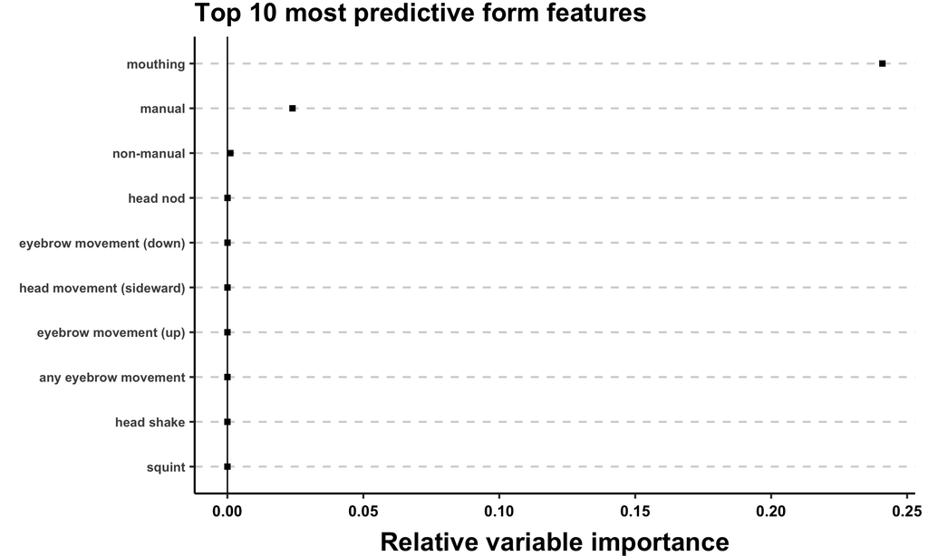

```r
## Setup plot basics:

polar_p <- importances %>%
  ggplot(aes(x = reorder(predictor, importance), y = importance))

## Add geoms:

polar_p <- polar_p +
  geom_hline(yintercept = abs(min(importances$importance)),
             lwd = 0.5) +
  geom_point(shape = 15, size = 2) +
  coord_flip()

## Axes and labels:

polar_p <- polar_p +
  xlab(NULL) +
  ylab('Relative variable importance')

# Themes:

polar_p <- polar_p +
  theme_BSL() +
  theme(axis.text.y = element_text(face = 'bold', size = 10),
        axis.title.x = element_text(face = 'bold',
                                     margin = margin(t = 10, b = 0,
                                                     r = 0, l = 0),
                                     size = 20),
        panel.grid.major.y = element_line(color = 'lightgrey',
                                          linetype = 'dashed'),
        plot.margin = margin(t = 0, b = 0,
                             r = 10, l = 15)) +
  ggtitle('Top 10 most predictive form features')

# Plot this:

polar_p
```

```r
ggsave(plot = polar_p,
       file = '../figures/pdf/variable_importances_polar.pdf',
       width = 10, height = 6)
ggsave(plot = polar_p,
       file = '../figures/png/variable_importances_polar.png',
       width = 10, height = 6)
```

What would the accuracy be if we used presence/absence of mouthing and presence/absence of manual question sign as simple heuristic?

```r
mouthing_tab <- with(df, table(mouthing_question, semantic))

# Add "multiple" and "single" (since they are both present):

mouthing_tab[2, ] <- mouthing_tab[2, ] + mouthing_tab[3, ]
mouthing_tab <- mouthing_tab[-3, ]

# Show:

mouthing_tab
```

```
##                  semantic
## mouthing_question Content Polar
##          Absent        35   403
##          Multiple     105    13
```

The diagonal are the *incorrect* cases here:

```r
1 - sum(diag(mouthing_tab)) / sum(mouthing_tab)
```

```
## [1] 0.9136691
```

```r
sum(diag(mouthing_tab)) / sum(mouthing_tab)
```

```
## [1] 0.08633094
```

91.4% correctness.

Let’s check the same for presence/absence of manual:

```r
manual_tab <- with(df, table(manual, semantic))

# Add "multiple" and "single" (since they are both present):

manual_tab[2, ] <- manual_tab[2, ] + manual_tab[3, ]
manual_tab <- manual_tab[-3, ]

# Show:

manual_tab
```

```
##           semantic
## manual     Content Polar
##   Absent        34   357
##   Multiple     106    59
```

The diagonal are the *incorrect* cases here:

```r
1 - sum(diag(manual_tab)) / sum(manual_tab)
```

```
## [1] 0.8327338
```

```r
sum(diag(manual_tab)) / sum(manual_tab)
```

```
## [1] 0.1672662
```

83.3% correctness.

Check for the next-most, nonmanuals:

```r
nonmanual_tab <- with(df, table(nonmanual, semantic))

# Show:

nonmanual_tab
```

```
##          semantic
## nonmanual Content Polar
##   Absent        5     7
##   Present     135   409
```

The diagonal are the *incorrect* cases here:

```r
1 - sum(diag(nonmanual_tab)) / sum(nonmanual_tab)
```

```
## [1] 0.2553957
```

```r
sum(diag(nonmanual_tab)) / sum(nonmanual_tab)
```

```
## [1] 0.7446043
```

This completes this analysis.